# Algorithmus

Es gibt keine allgemeingültige Definition für einen Algorithmus. Je nach Sichtweise, Arbeitsgebiet und Problemstellung bieten sich verschiedene Definitionen an.

Mögliche Definitionen sind:

> - Er ist eine Menge von Regeln, die ein Problem lösen. Die Regeln können entweder von einer Maschine oder manuell ausgeführt werden.
> - Er ist eine Menge von Anweisungen, die garantiert in einer endlichen Anzahl von Schritten eine korrekte Lösung für jede Instanz eines gegebenen Problems finden.
> - Er ist eine Sequenz von Schritten, die die Eingabedaten in die gewünschten Resultate transformieren.
> - Er ist eine Folge von Operationen, die die Daten in Datenstrukturen organisieren.
> - Er ist die Abstraktion eines Programms, das auf einer physischen Maschine oder auf einem Rechnermodell ausgeführt wird

> *Quelle D. Logofătu, Grundlegende Algorithmen mit Java*

Dementsprechend können Algorithmen auch verschiedenen Darstellungsformen haben. Jeder hat schon mal einen Algorithmus abgearbeitet.

### Beispiel-Algorithmus: Zubereitung eines Butterbrots

Handlungsanweisungen wie Rezepte können als Algorithmus verstanden werden.

1. Hole ein Brot.
2. Hole Butter.
3. Schneide ein Stück Brot ab.
4. Schneide ein hinreichend großes Stück Butter ab.
5. Verteile die Butter auf der Oberseite der Brotscheibe.

### Beispiel: Suche

Ein klassisches und häufiges Problem in der Informatik ist die Suche.

Es ist vergleichbar mit der Suche in einem Wörterbuch. Wenn Sie nach einem Wort mit `M` am Anfang suchen, haben Sie die Möglichkeit, jedes Wort beginnend ab dem Anfang mit dem gesuchten Wort zu vergleichen. Dieses Vorgehen wird auch als **sequentielle Suche** bezeichnet. Es dauert mitunter sehr lange und ist nicht effizient. Wahrscheinlich werden Sie aber in der Mitte des Buches anfangen zu suchen und je nachdem welches Wort sie dort finden mehrere Seiten vor oder zurückblättern. Sie nutzen damit die Eigenschaft, dass alle Wörter im Buch sortiert sind.

Ein ähnliches Problem tritt auf, wenn Sie sich bei einem großen online Anbieter mit ihrem Nutzernamen (z. B. `karlkoch`) anmelden. Hier werden auch nicht alle Milliarden Accounts (gesamter Datenbestand) mit dem Namen verglichen, bis der passende gefunden ist. Sondern es wird eine effizientere Strategie genutzt. Dies ist ein Suchproblem.

#### Binäre Suche / binary search

**Binäre Suche** ist ein Algorithmus, der das Suchproblem löst. Seine Eingabedaten sind eine **sortierte Liste** von Elementen und ein Wert nach dem gesucht werden soll. Wird der Wert in den Elementen gefunden, dann wird die Position des Elements zurückgegeben. Ansonsten wird ein Wert zurückgegeben, der signalisiert, dass kein Element gefunden wurde.

#### Algorithmische Beschreibung

Die Liste in der gesucht werden soll hat `N` Elemente. Das gesuchte Element heißt `x`.

1. Setze `UntereGrenze = 1` und `ObereGrenze = N`
2. Bestimme die Mitte zwischen unterer und oberer Grenze `Mitte = (UntereGrenze + ObereGrenze) / 2`. (Gegebenenfalls muss abgerundet werden)
3. Wenn `x` dem Element an der Stelle `Mitte` entspricht, wurde die Position gefunden und der Algorithmus ist beendet. Es wird die Position (`Mitte`) zurückgegeben.
4. Falls `x` größer als der Wert an der Stelle Mitte ist, setze die untere Grenze auf den Wert der Mitte plus 1 (Der Suchraum wird halbiert).
5. Falls `x` kleiner als der Wert an der Stelle Mitte ist, setze die obere Grenze auf den Wert der Mitte minus 1(Der Suchraum wird halbiert).
6. Ist die `ObereGrenze` größer oder gleich `UntereGrenze` fahre mit Schritt 2. fort.
7. `x` wurde nicht gefunden. Der Algorithmus ist beendet.

#### Veranschaulichung

Dieser Algorithmus lässt sich gut an folgendem Spiel verdeutlichen: Eine Spielerin `A` denkt sich eine Zahl zwischen 1 und 100 aus. Eine zweite Mitspielerin `B` muss die Zahl in möglichst wenig Schritten raten. Nach jedem Tipp teilt Spielerin `A` mit, ob die gesuchte Zahl größer oder kleiner ist.

`B` hat nun die Möglichkeit alle Zahlen beginnend bei eins durchzuprobieren, oder sie nutzt die Information, ob ihr Tipp größer oder kleiner ist und wendet binäre Suche an.

Beispielablauf:

- A denkt sich die Zahl `43` aus.
- B tippt 50 ( `(1+100)/2` abgerundet)
- A sagt kleiner
- B tippt 25 ( `(1+49)/2`)
- A sagt größer
- B tippt 37 ( `(26+49)/2` abgerundet)
- A sagt größer
- B tippt 43 ( `(38+49)/2` abgerundet)
- A sagt treffer

Mittels binärer Suche wurde die gesuchte Zahl also in 4 Schritten gefunden.

#### Visualisierung

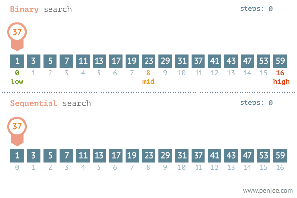

Animation binäre und sequentielle Suche [Quelle: https://blog.penjee.com/binary-vs-linear-search-animated-gifs/]

#### Weiterführende Links

- https://www.youtube.com/watch?v=P3YID7liBug
- https://s3.amazonaws.com/codecademy-content/courses/search-course/visualizations/binarySearchInteractive/binarySearchInteractive/empty-example/index.html
- https://www.youtube.com/watch?v=iP897Z5Nerk

# Übungen

## Übung 1: Eigener Algorithmus

Beschreiben Sie eine Alltagssituation bzw. Handlung als Algorithmus.

## Übung 2: Zahlensuchspiel

1. Geben Sie eine Zahl für das Suchspiel an, bei dem die binäre Suche möglichst lange braucht.
2. Geben Sie alle Schritten wie im Beispiel an.
3. Notieren Sie wie viele Werte nach jedem Schritt ausgeschlossen werden.
4. Ermitteln Sie die Anzahl an Schritten/Tipps die benötigt wurden.

## Übung 3: Binäre Suche

Betrachten Sie folge Liste von Zahlen (Insgesamt 30)

```
Position: 1,  2,  3,  4,  5,  6,  7,  8,  9, 10, 11, 12, 13, 14, 15,  16,  17,  18,  19,  20,  21,  22,  23,  24,  25,  26,  27,  28,  29,  30

Wert:    10, 12, 19, 20, 26, 27, 37, 43, 48, 73, 75, 86, 87, 90, 93, 113, 116, 118, 126, 136, 143, 147, 154, 162, 169, 172, 180, 182, 183, 195
```

1. Es wird die Zahl 12 gesucht. Geben Sie die Schritte an, die von der binären Suche gemacht werden.
   1. UntereGrenze = 1 und ObereGrenze=30
   2. Mitte=15
   3. 12 ist kleiner als 93 (Wert an Position 15) also ObereGrenze=14
   4. Mitte=7 …
2. Es wird die Zahl `180` gesucht. Geben Sie die Schritte an, die von der binären Suche gemacht werden. Geben Sie die Schritte des Algorithmus in folgender Tabelle an:

   | UG | OG | Mitte | Wert Mitte | gesuchter Wert kleiner/größer | Konsequenz |
   | --- | --- | --- | --- | --- | --- |
   | 1 | 30 | 15 | 93 | 180 ist größer | UG=16 |
   | 16 | 30 | … | … | … | … |

3. Es wird die Zahl `5` gesucht. Geben Sie die Schritte an, die von der binären Suche gemacht werden. Geben Sie die Schritte ebenfalls in Tabellenform an.
4. Notieren Sie für die drei Suchen wie viele Werte nach jedem Schritt ausgeschlossen werden.